# examples_0326

Label the four transformations below:

## Transformation 1

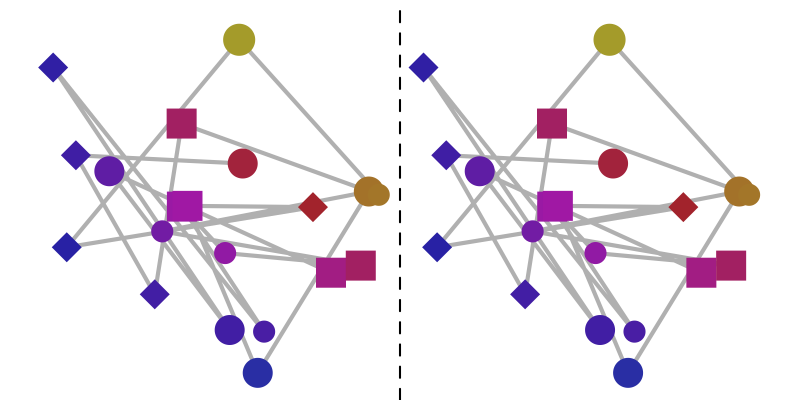

## Transformation 2

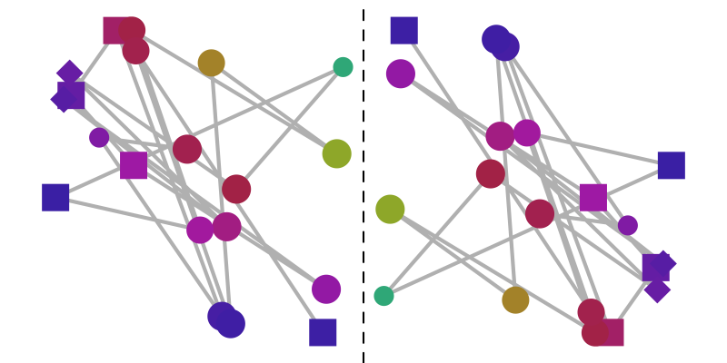

## Transformation 3

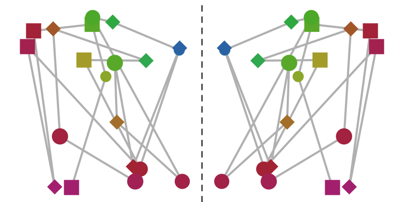

## Transformation 4

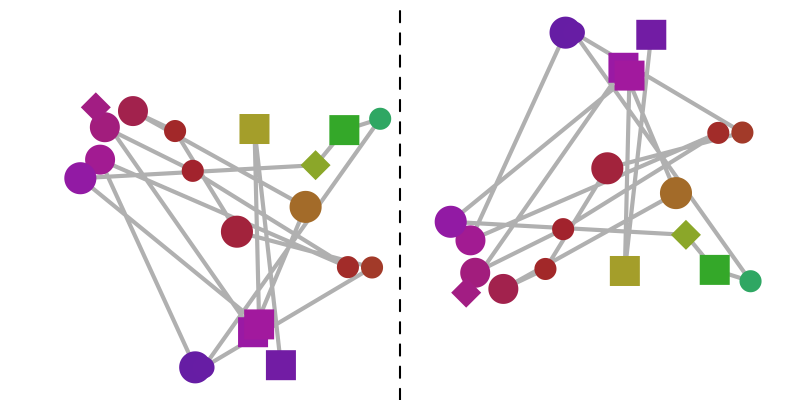

- Transformation 1: translation.
- Transformation 2: rotation.
- Transformation 3: mirror.
- Transformation 4: glide.

1, 2, 4, 3

Label the four transformations below:

## Transformation 1

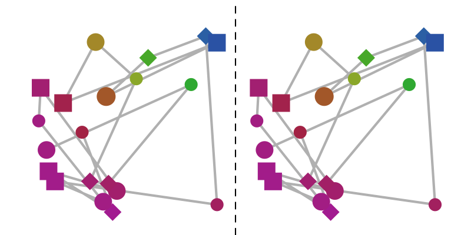

## Transformation 2

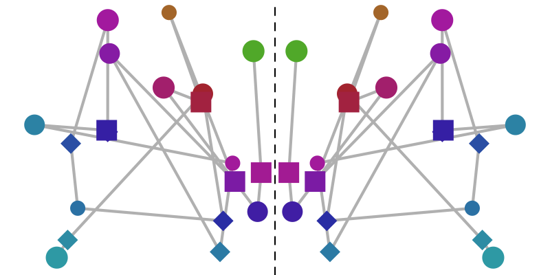

## Transformation 3

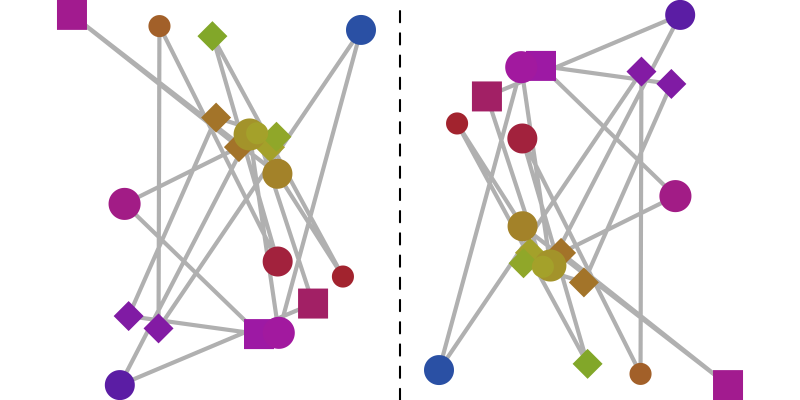

## Transformation 4

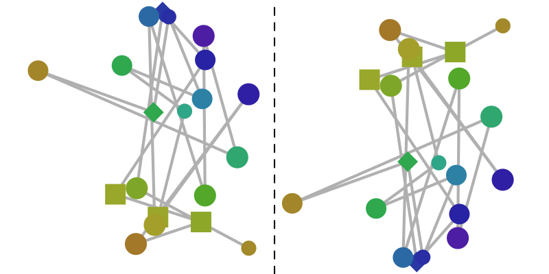

- Transformation 1: translation.
- Transformation 2: mirror.
- Transformation 3: rotation.
- Transformation 4: glide.

1, 4, 2, 3

Label the four transformations below:

## Transformation 1

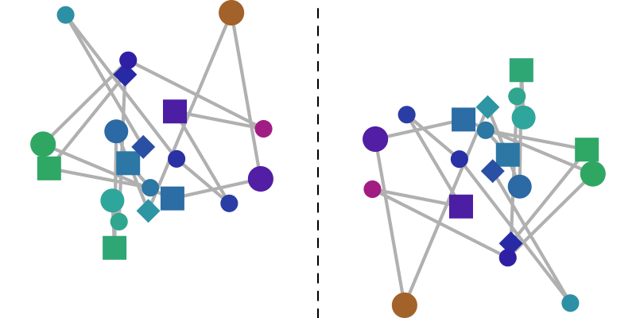

## Transformation 2

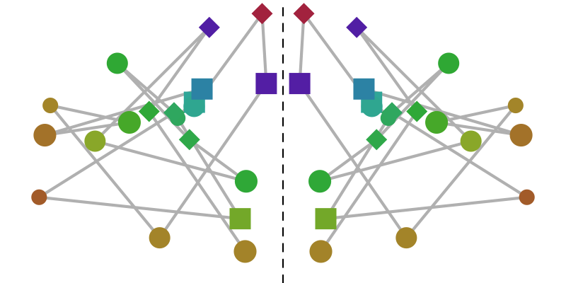

## Transformation 3

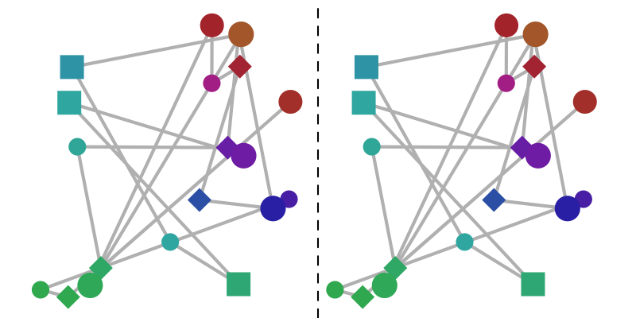

## Transformation 4

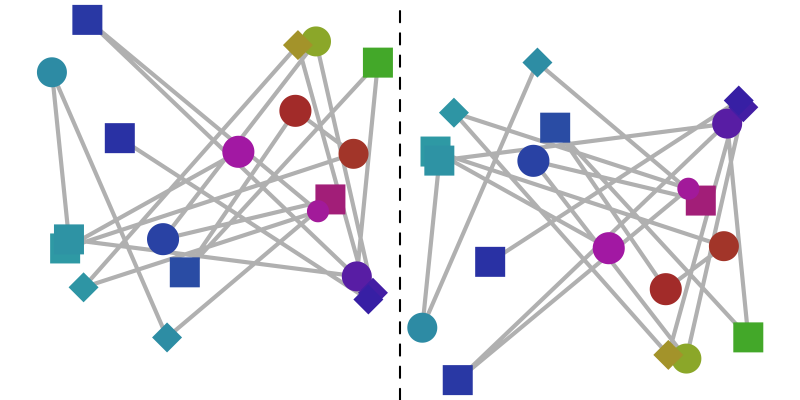

- Transformation 1: rotation.
- Transformation 2: mirror.
- Transformation 3: translation.
- Transformation 4: glide.

2, 4, 1, 3

Label the four transformations below:

## Transformation 1

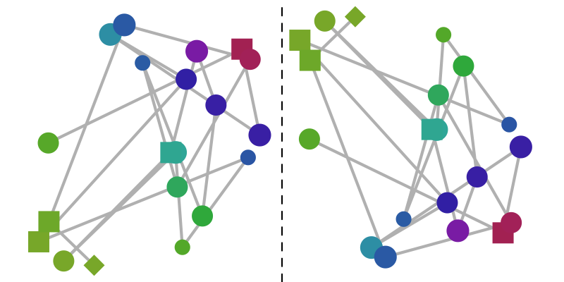

## Transformation 2

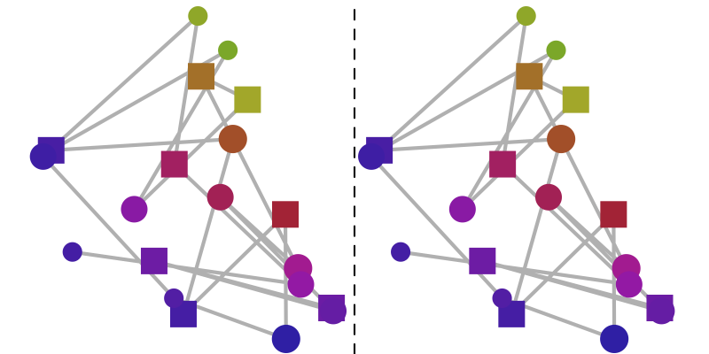

## Transformation 3

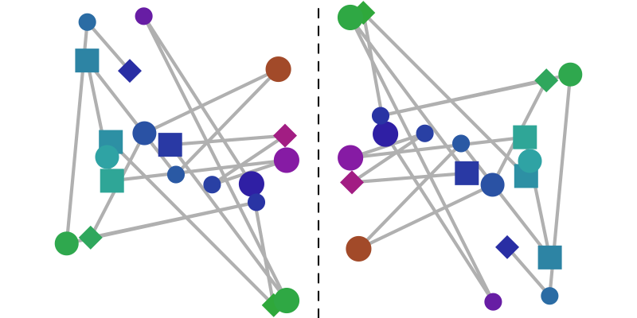

## Transformation 4

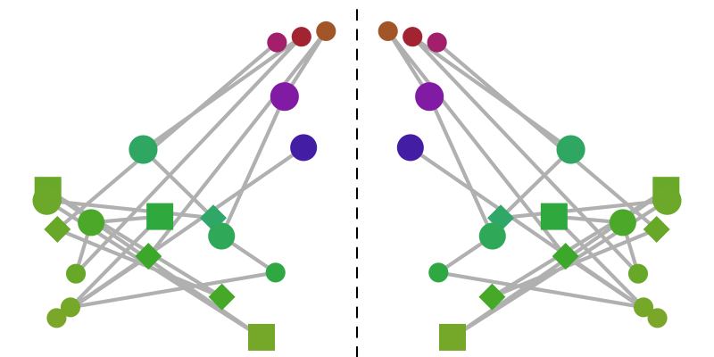

- Transformation 1: glide.
- Transformation 2: translation.
- Transformation 3: rotation.
- Transformation 4: mirror.

3, 1, 2, 4

For each of the patterns below, determine the Frieze group.

## Pattern 1

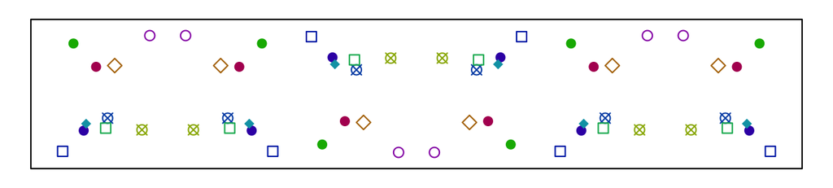

Match the IUC name:

## Pattern 2

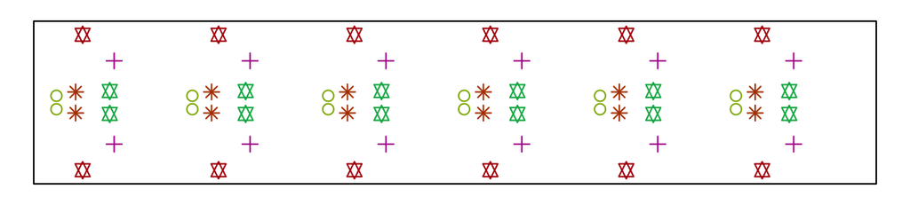

Match the Conway nickname:

- The first pattern is a p2mg (which is also called spinning sidle).
- The second pattern is a jump (which is also called p11m).

For each of the patterns below, determine the Frieze group.

## Pattern 1

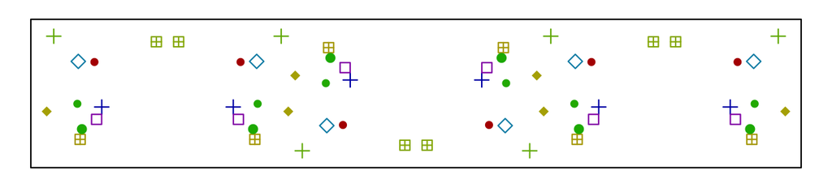

Match the IUC name:

## Pattern 2

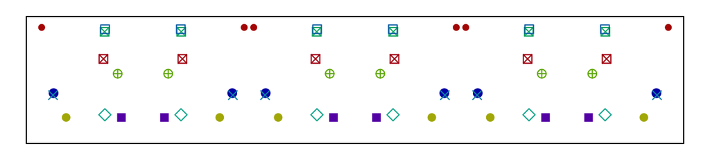

Match the Conway nickname:

- The first pattern is a p2mg (which is also called spinning sidle).
- The second pattern is a sidle (which is also called p1m1).

For each of the patterns below, determine the Frieze group.

## Pattern 1

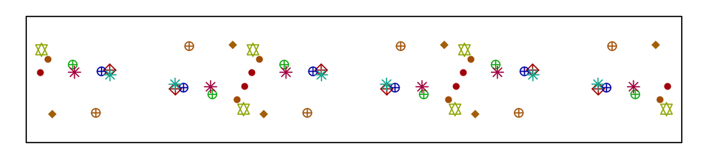

Match the IUC name:

## Pattern 2

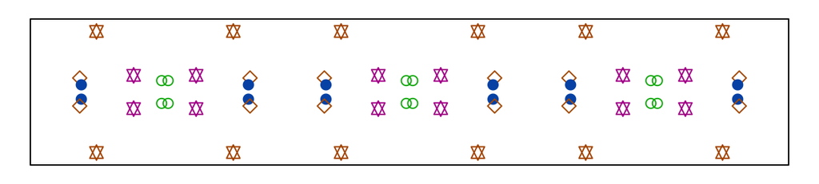

Match the Conway nickname:

- The first pattern is a p2 (which is also called spinning hop).
- The second pattern is a spinning jump (which is also called p2mm).

For each of the patterns below, determine the Frieze group.

## Pattern 1

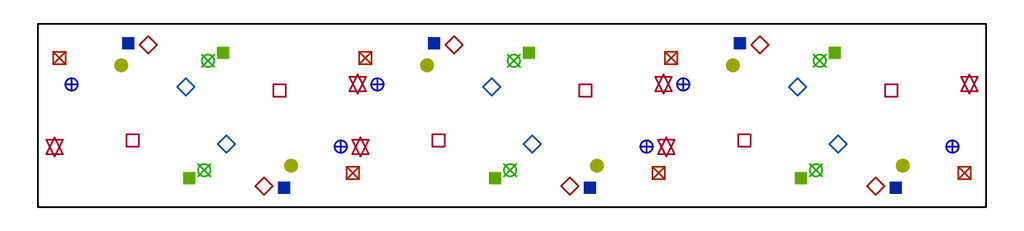

Match the IUC name:

## Pattern 2

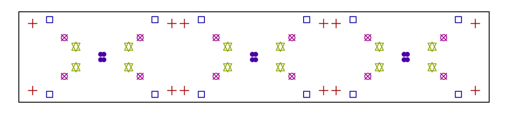

Match the Conway nickname:

- The first pattern is a p2 (which is also called spinning hop).
- The second pattern is a spinning jump (which is also called p2mm).

A turtle starts at the star in the middle, facing North. She walks forward for a while, then turns 60° either to her right (clockwise) or to her left (counterclockwise). She repeats this, marking her path with various colors, until she has drawn 6 segments.

The distance between adjacent dots is 1 unit.

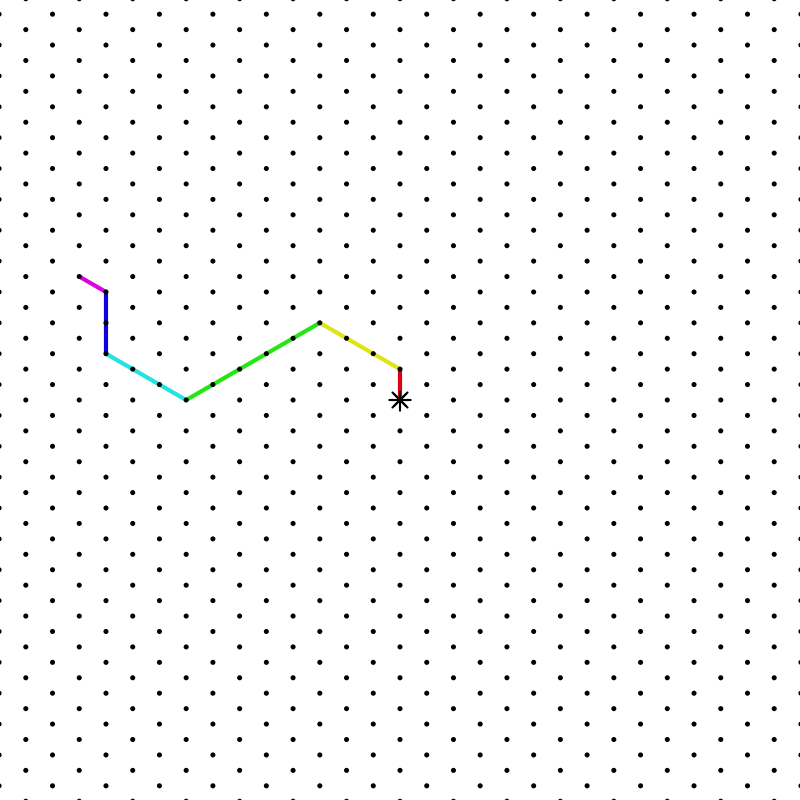

Describe the path taken by the turtle.

A turtle starts at the star in the middle, facing North. She walks forward for a while, then turns 60° either to her right (clockwise) or to her left (counterclockwise). She repeats this, marking her path with various colors, until she has drawn 6 segments.

The distance between adjacent dots is 1 unit.

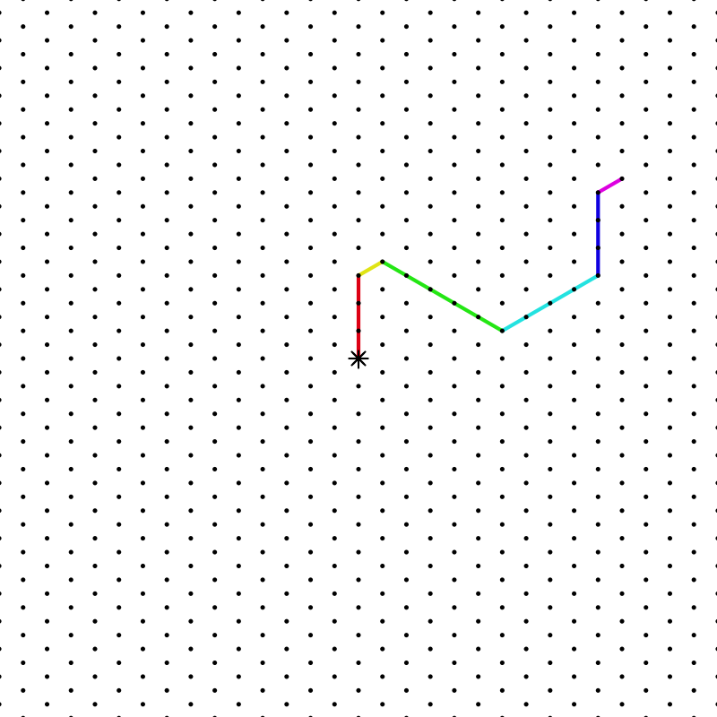

Describe the path taken by the turtle.

A turtle starts at the star in the middle, facing North. She walks forward for a while, then turns 60° either to her right (clockwise) or to her left (counterclockwise). She repeats this, marking her path with various colors, until she has drawn 6 segments.

The distance between adjacent dots is 1 unit.

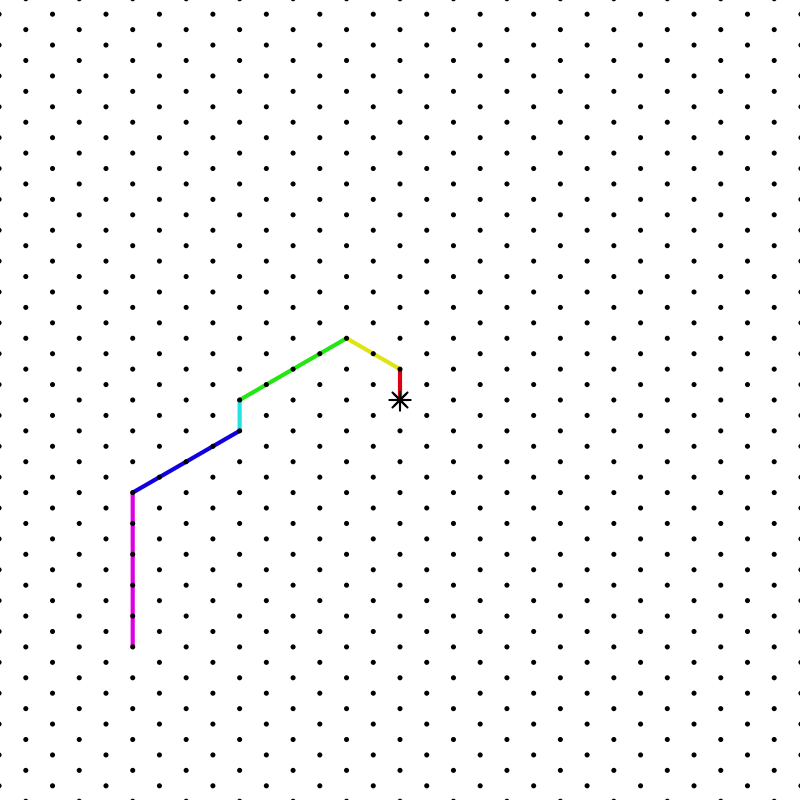

Describe the path taken by the turtle.